# LAB03CDP

José Glauber

31 de outubro de 2018

## Importanto os dados e bibliotecas necessárias para as respostas das questões!

```r
knitr::opts_chunk$set(echo = TRUE, warning=FALSE, message=FALSE)
library(readr)
library(caret)
library(dplyr)
library(ggplot2)
```

# Carregando informações e retirando informações que não são interessantes para o nosso modelo (discutido anteriormente)

```r
train_set <- read.csv("train.csv")
train <- train_set %>% select(-cargo, -nome, -sequencial_candidato, -ocupacao)
```

## Perguntas

1. Usando todas as variáveis disponíveis, tune (usando validação cruzada): (i) um modelo de regressão Ridge, (ii) um modelo de regressão Lasso e (iii) um modelo KNN. Para os modelos de regressão linear, o parâmetro a ser tunado é o lambda (penalização dos coeficientes) e o KNN o número de vizinhos.

# Validação cruzada

```r
train_control <- trainControl(method = "cv", number = 5)
preProcValues <- c("center", "scale", "nzv")
```

1. um modelo de regressão Ridge

```r
model.ridge <- train(votos ~ .,
               data = train,
               trControl = train_control,
               method = "ridge",
               preProcess = preProcValues,
               tuneLength = 20)
model.ridge
```

```
Ridge Regression

7476 samples
  19 predictor

Pre-processing: centered (32), scaled (32), remove (49)
Resampling: Cross-Validated (5 fold)
Summary of sample sizes: 5981, 5982, 5980, 5980, 5981
Resampling results across tuning parameters:

  lambda        RMSE      Rsquared   MAE
  0.0000000000  38862.18  0.3684213  16229.19
  0.0001000000  38852.92  0.3685770  16228.27
  0.0001467799  38851.58  0.3686148  16228.56
  0.0002154435  38849.82  0.3686661  16228.98
  0.0003162278  38847.63  0.3687328  16229.58
  0.0004641589  38845.17  0.3688145  16230.45
  0.0006812921  38842.90  0.3689053  16231.73
  0.0010000000  38841.80  0.3689894  16233.59
  0.0014677993  38843.58  0.3690373  16236.13
  0.0021544347  38850.72  0.3690045  16240.25
  0.0031622777  38866.27  0.3688366  16245.50
  0.0046415888  38893.33  0.3684819  16251.58
  0.0068129207  38934.32  0.3679084  16258.88
  0.0100000000  38990.57  0.3671183  16267.83
  0.0146779927  39062.30  0.3661513  16275.95
  0.0215443469  39149.61  0.3650748  16279.94
  0.0316227766  39253.98  0.3639609  16275.97
  0.0464158883  39380.39  0.3628639  16258.15
  0.0681292069  39539.70  0.3618020  16222.88
  0.1000000000  39751.97  0.3607520  16173.82

RMSE was used to select the optimal model using the smallest value.
The final value used for the model was lambda = 0.001.
```

2. O modelo de regressão Lasso

```r
model.lasso <- train(votos ~ .,
                     data = train,
                     trControl = train_control,
                     method = "lasso",
                     preProcess = preProcValues,
                     tuneLength = 20)
model.lasso
```

```
The lasso

7476 samples
  19 predictor

Pre-processing: centered (32), scaled (32), remove (49)
Resampling: Cross-Validated (5 fold)
Summary of sample sizes: 5981, 5981, 5981, 5980, 5981
Resampling results across tuning parameters:

  fraction   RMSE       Rsquared   MAE
  0.1000000   41536.70  0.3600295  16440.28
  0.1421053   44217.26  0.3505349  16529.77
  0.1842105   47178.15  0.3448863  16619.26
  0.2263158   50298.17  0.3414386  16708.75
  0.2684211   53514.55  0.3392335  16798.24
  0.3105263   56792.87  0.3377564  16887.73
  0.3526316   60113.01  0.3367259  16977.22
  0.3947368   63462.60  0.3359814  17066.71
  0.4368421   66833.66  0.3354275  17156.20
  0.4789474   70220.80  0.3350050  17245.70
  0.5210526   73620.29  0.3346757  17335.19
  0.5631579   77029.47  0.3344143  17425.03
  0.6052632   80446.39  0.3342034  17514.92
  0.6473684   83869.56  0.3340308  17604.81
  0.6894737   87297.89  0.3338879  17694.70
  0.7315789   90730.49  0.3337682  17784.60
  0.7736842   94166.68  0.3336669  17874.49
  0.8157895   97605.92  0.3335805  17964.38
  0.8578947  101047.76  0.3335062  18054.28
  0.9000000  104491.85  0.3334419  18144.17

RMSE was used to select the optimal model using the smallest value.
The final value used for the model was fraction = 0.1.
```

3. O modelo KNN

```r
model.knn <- train(votos ~ .,
                   data = train,
                   method = "knn",
                   trControl = train_control,
                   preProcess = preProcValues,
                   tuneLength = 20)
model.knn
```

```
k-Nearest Neighbors

7476 samples
  19 predictor

Pre-processing: centered (32), scaled (32), remove (49)
Resampling: Cross-Validated (5 fold)
Summary of sample sizes: 5980, 5981, 5982, 5981, 5980
Resampling results across tuning parameters:

  k   RMSE      Rsquared   MAE
   5  35321.77  0.4591572  13796.03
   7  35409.65  0.4588469  13761.65
   9  35213.89  0.4668085  13733.18
  11  35191.48  0.4696443  13810.77
  13  35355.92  0.4655660  13906.92
  15  35441.87  0.4648515  14020.31
  17  35324.91  0.4701360  14022.58
  19  35450.74  0.4667672  14126.36
  21  35555.06  0.4641643  14224.33
  23  35597.96  0.4636921  14291.09
  25  35735.91  0.4603212  14343.77
  27  35785.47  0.4588820  14395.39
  29  35814.65  0.4589753  14434.69
  31  35844.18  0.4589427  14505.46
  33  35938.99  0.4563668  14539.42
  35  36020.86  0.4540763  14597.44
  37  36082.52  0.4528801  14639.40
  39  36161.79  0.4506510  14676.27
  41  36205.02  0.4498071  14699.43
  43  36235.17  0.4493432  14727.62

RMSE was used to select the optimal model using the smallest value.
The final value used for the model was k = 11.
```

2. Compare os três modelos em termos do erro RMSE de validação cruzada.

RMSE do modelo ridge: 38841.80 RMSE do modelo lasso: 41536.70 RMSE do modelo knn: 35191.48

Podemos verificar que dentro os modelos, o menor RMSE é o do modelo KNN, em seguida temos o do Ridge e por último, o Lasso.

3. Quais as variáveis mais importantes segundo o modelo de regressão Ridge e Lasso? Variáveis foram descartadas pelo Lasso? Quais?

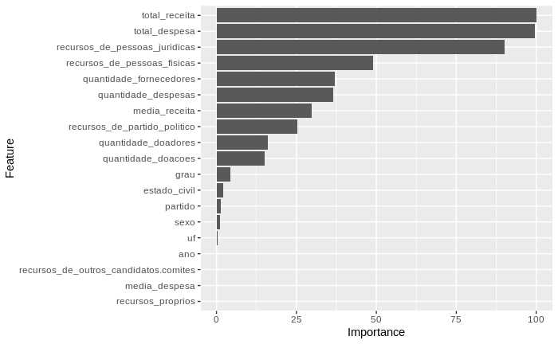

```r
ggplot(varImp(model.ridge))
```

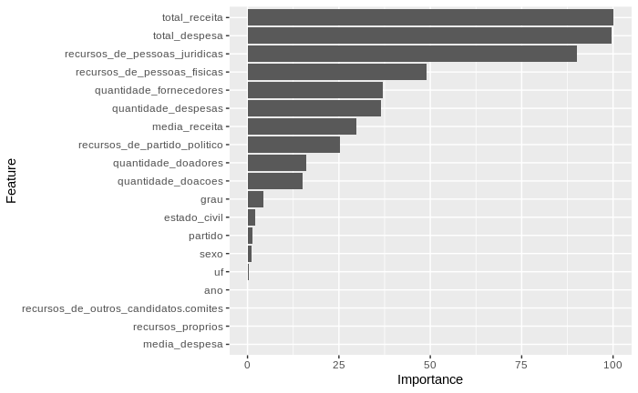

```r
ggplot(varImp(model.lasso))
```

4. Re-treine o melhor modelo (usando os melhores valores de parâmetros encontrados em todos os dados, sem usar validação cruzada).

```r
best <- expand.grid(k = model.knn$bestTune)
best.model <- train(votos ~ .,
                    data = train,
                    method = "knn",
                    tuneGrid = best)
best.model
```

```
k-Nearest Neighbors

7476 samples
  19 predictor

No pre-processing
Resampling: Bootstrapped (25 reps)
Summary of sample sizes: 7476, 7476, 7476, 7476, 7476, 7476, ...
Resampling results:

  RMSE      Rsquared   MAE
  35102.95  0.4737995  12835.49

Tuning parameter 'k' was held constant at a value of 11
```

5. Use esse último modelo treinado para prever os dados de teste disponíveis no challenge que criamos na plataforma Kaggle.

```r
test <- read.csv("test.csv")
submission <- test %>%
  select(sequencial_candidato)
test <- test %>%
  select(-sequencial_candidato,
         -nome,
         -cargo,
         -ocupacao)
predictions <- predict(best.model, test)
submission$votos <- predictions
submission <- submission %>%
  select(ID = sequencial_candidato,
         votos = votos)
write.csv(x = submission,
          file = "sample_submission.csv",
          row.names = FALSE)
```